# Geospatial risk modeling - the case of crime

Anyang

2019/11/5

# 1.1 Data Wrangling

```r
library(tidyverse)
library(sf)
library(QuantPsyc)
library(RSocrata)
library(viridis)
library(caret)
library(spatstat)
library(spdep)
library(FNN)
library(grid)
library(gridExtra)
library(knitr)
library(kableExtra)
library(tidycensus)

mapTheme <- function(base_size = 12) {
  theme(
    text = element_text( color = "black"),
    plot.title = element_text(size = 14,colour = "black"),
    plot.subtitle=element_text(face="italic"),
    plot.caption=element_text(hjust=0),
    axis.ticks = element_blank(),
    panel.background = element_blank(),axis.title = element_blank(),
    axis.text = element_blank(),
    axis.title.x = element_blank(),
    axis.title.y = element_blank(),
    panel.grid.minor = element_blank(),
    panel.border = element_rect(colour = "black", fill=NA, size=2)
  )
}
```

In this model, the algorithm was developed to borrow the theft experience in places theft has been observed in Chicago, and test whether that experience generalizes to places where the risk is ‘latent’.It uses the collected spatial structure variables to predicted the chicago hot spots.

The interest here is the theft cases of crimes. The following is the map of cirme points in Chicago.It is possible that the selection bias is exist in my model.It is possible that people with a high propensity to select theft cases or report it with the selection bias of race.The selection bias also can be the different education level block groups. To some extent, it is possible that the low-educated people’s behavior will be magnified.

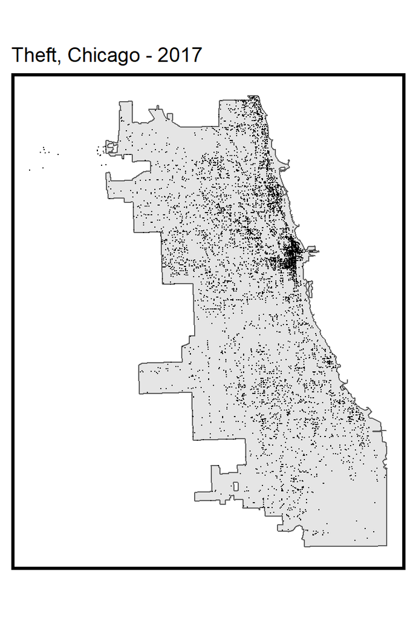

```r
policeDistricts <-
  st_read("https://data.cityofchicago.org/api/geospatial/fthy-xz3r?method=export&format=GeoJSON") %>%
  st_transform(crs=102271) %>%
  dplyr::select(District = dist_num)
## Reading layer `OGRGeoJSON' from data source `https://data.cityofchicago.org/api/geospatial/fthy-xz3r?method=export&format=GeoJSON' using driver `GeoJSON'
## Simple feature collection with 25 features and 2 fields
## geometry type:  MULTIPOLYGON
## dimension:      XY
## bbox:           xmin: -87.94011 ymin: 41.64455 xmax: -87.52414 ymax: 42.02303
## epsg (SRID):    4326
## proj4string:    +proj=longlat +datum=WGS84 +no_defs

policeBeats <-
  st_read("https://data.cityofchicago.org/api/geospatial/aerh-rz74?method=export&format=GeoJSON") %>%
  st_transform(crs=102271) %>%
  dplyr::select(District = beat_num)
## Reading layer `OGRGeoJSON' from data source `https://data.cityofchicago.org/api/geospatial/aerh-rz74?method=export&format=GeoJSON' using driver `GeoJSON'
## Simple feature collection with 277 features and 4 fields
## geometry type:  MULTIPOLYGON
## dimension:      XY
## bbox:           xmin: -87.94011 ymin: 41.64455 xmax: -87.52414 ymax: 42.02303
## epsg (SRID):    4326
## proj4string:    +proj=longlat +datum=WGS84 +no_defs

bothPoliceUnits <- rbind(mutate(policeDistricts, Legend = "Police Districts"),
                         mutate(policeBeats, Legend = "Police Beats"))

chicagoBoundary <-
  st_read("/Users/Anyang/Documents/R/MUSA/MUSA 507/Geospatial risk modeling/riskPrediction_data/chicagoBoundary.shp") %>%
  st_transform(crs=102271)
## Reading layer `chicagoBoundary' from data source `C:\Users\Anyang\Documents\R\MUSA\MUSA 507\Geospatial risk modeling\riskPrediction_data\chicagoBoundary.shp' using driver `ESRI Shapefile'
## Simple feature collection with 1 feature and 1 field
## geometry type:  POLYGON
## dimension:      XY
## bbox:           xmin: 341164.1 ymin: 552875.4 xmax: 367345.4 ymax: 594870
## epsg (SRID):    NA
## proj4string:    +proj=tmerc +lat_0=36.66666666666666 +lon_0=-88.33333333333333 +k=0.9999749999999999 +x_0=300000 +y_0=0 +ellps=GRS80 +units=m +no_defs

fishnet <-
  st_make_grid(chicagoBoundary, cellsize = 500) %>%
  st_sf()

fishnet <-
  fishnet[chicagoBoundary,] %>%
  mutate(uniqueID = rownames(.)) %>%
  dplyr::select(uniqueID)

theft <- readRDS("C:/Users/Anyang/Documents/R/MUSA/MUSA 507/Geospatial risk modeling/theft.rds")

ggplot() +
  geom_sf(data = chicagoBoundary) +
  geom_sf(data = theft, colour="black", size=0.05, show.legend = "point") +
  labs(title= "Theft, Chicago - 2017") +
  mapTheme()
```

## 1.2 Joining the Theft to the fishnet

In this model, It creates and refers to this grid cell lattice as the fishnet.The fishnet is used to aggregate point phenomena to a lattice of grid cells.It is used to represent smooth spatial surface which varies across administrative units. Then, calculating the count of theft cases.

Joining the sum theft cases to the fishnet. The following is the map of the count of theftlaries by grid cell, and the spatial structure of theft is created in the map below as the hotspots are apparent.

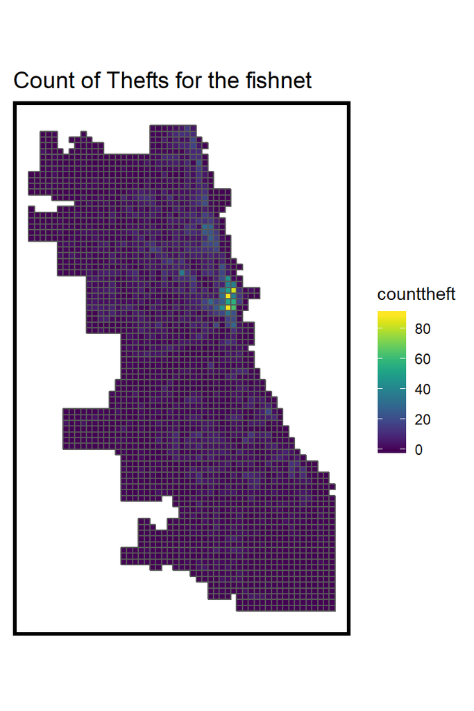

```r
theft_net <-
  theft %>%
  dplyr::select() %>%
  mutate(counttheft = 1) %>%
  aggregate(., fishnet, sum) %>%
  mutate(counttheft = ifelse(is.na(counttheft), 0, counttheft),
         uniqueID = rownames(.),
         cvID = sample(round(nrow(fishnet) / 24), size=nrow(fishnet), replace = TRUE))

ggplot() +
  geom_sf(data = theft_net, aes(fill = counttheft)) +
  scale_fill_viridis() +
  labs(title = "Count of Thefts for the fishnet") +
  mapTheme()
```

# 2.1 Data Wrangling Risk Factors

The model use ten risk factors and a neighborhood polygon layer. The data includes 311 calls for: Missed garbage, Tree trims, Building violation, Traffic sign out, Street lights out, Graffiti remediation, Sanitation complaints, Abandoned cars, The location of liquor retail,Abandoned buildings.

There are the maps of risk factors in points.

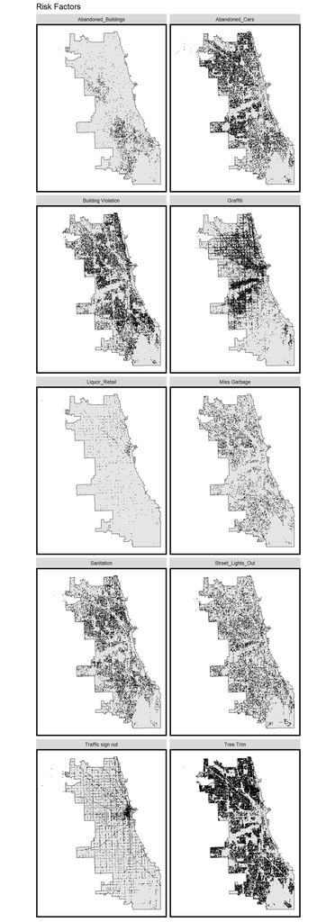

```r
Buildingviolation <- readRDS("C:/Users/Anyang/Documents/R/MUSA/MUSA 507/Geospatial risk modeling/Buildingviolation.rds")%>%
  dplyr::select(Y = latitude, X = longitude) %>%
  na.omit() %>%
  st_as_sf(coords = c("X", "Y"), crs = 4326, agr = "constant") %>%
  st_transform(st_crs(fishnet)) %>%
  mutate(Legend = "Building Violation")

Treetrim <- readRDS("C:/Users/Anyang/Documents/R/MUSA/MUSA 507/Geospatial risk modeling/Treetrim.rds")%>%
  dplyr::select(Y = latitude, X = longitude) %>%
  na.omit() %>%
  st_as_sf(coords = c("X", "Y"), crs = 4326, agr = "constant") %>%
  st_transform(st_crs(fishnet)) %>%
  mutate(Legend = "Tree Trim")

Trafficsignout <- readRDS("C:/Users/Anyang/Documents/R/MUSA/MUSA 507/Geospatial risk modeling/Trafficsignout.rds")%>%
  dplyr::select(Y = latitude, X = longitude) %>%
  na.omit() %>%
  st_as_sf(coords = c("X", "Y"), crs = 4326, agr = "constant") %>%
  st_transform(st_crs(fishnet)) %>%
  mutate(Legend = "Traffic sign out")

missgarbage <- readRDS("C:/Users/Anyang/Documents/R/MUSA/MUSA 507/Geospatial risk modeling/missgarbage.rds")%>%
  dplyr::select(Y = latitude, X = longitude) %>%
  na.omit() %>%
  st_as_sf(coords = c("X", "Y"), crs = 4326, agr = "constant") %>%
  st_transform(st_crs(fishnet)) %>%
  mutate(Legend = "Miss Garbage")

graffiti <-
  read.socrata("https://data.cityofchicago.org/Service-Requests/311-Service-Requests-Graffiti-Removal-Historical/hec5-y4x5") %>%
    mutate(year = substr(creation_date,1,4)) %>%
    filter(year == "2017") %>%
    filter(where_is_the_graffiti_located_ == "Front" |
           where_is_the_graffiti_located_ == "Rear" | where_is_the_graffiti_located_ == "Side") %>%
    dplyr::select(Y = latitude, X = longitude) %>%
  na.omit() %>%
  st_as_sf(coords = c("X", "Y"), crs = 4326, agr = "constant") %>%
  st_transform(st_crs(fishnet)) %>%
  mutate(Legend = "Graffiti")

streetLightsOut <-
  read.socrata("https://data.cityofchicago.org/Service-Requests/311-Service-Requests-Street-Lights-All-Out/zuxi-7xem") %>%
    mutate(year = substr(creation_date,1,4)) %>%
    filter(year == "2017") %>%
    dplyr::select(Y = latitude, X = longitude) %>%
  na.omit() %>%
  st_as_sf(coords = c("X", "Y"), crs = 4326, agr = "constant") %>%
  st_transform(st_crs(fishnet)) %>%
  mutate(Legend = "Street_Lights_Out")

sanitation <-
  read.socrata("https://data.cityofchicago.org/Service-Requests/311-Service-Requests-Sanitation-Code-Complaints-Hi/me59-5fac") %>%
    mutate(year = substr(creation_date,1,4)) %>%
    filter(year == "2017") %>%
    dplyr::select(Y = latitude, X = longitude) %>%
  na.omit() %>%
  st_as_sf(coords = c("X", "Y"), crs = 4326, agr = "constant") %>%
  st_transform(st_crs(fishnet)) %>%
  mutate(Legend = "Sanitation")

liquorRetail <-
  read.socrata("https://data.cityofchicago.org/Community-Economic-Development/Business-Licenses-Cur   rent-Liquor-and-Public-Places/nrmj-3kcf") %>%
  filter(BUSINESS.ACTIVITY == "Retail Sales of Packaged Liquor") %>%
  dplyr::select(Y = LATITUDE, X = LONGITUDE) %>%
  na.omit() %>%
  st_as_sf(coords = c("X", "Y"), crs = 4326, agr = "constant") %>%
  st_transform(st_crs(fishnet)) %>%
  mutate(Legend = "Liquor_Retail")

abandonCars <-
  read.socrata("https://data.cityofchicago.org/Service-Requests/311-Service-Requests-Abandoned-Vehicles/3c9v-pnva") %>%
  mutate(year = substr(creation_date,1,4)) %>%
  filter(year == "2017") %>%
  dplyr::select(Y = latitude, X = longitude) %>%
  na.omit() %>%
  st_as_sf(coords = c("X", "Y"), crs = 4326, agr = "constant") %>%
  st_transform(st_crs(fishnet)) %>%
  mutate(Legend = "Abandoned_Cars")

abandonBuildings <-
  read.socrata("https://data.cityofchicago.org/Service-Requests/311-Service-Requests-Vacant-and-Abandoned-Building/7nii-7srd") %>%
    mutate(year = substr(date_service_request_was_received,1,4)) %>%
    filter(year == "2017") %>%
    dplyr::select(Y = latitude, X = longitude) %>%
  na.omit() %>%
  st_as_sf(coords = c("X", "Y"), crs = 4326, agr = "constant") %>%
  st_transform(st_crs(fishnet)) %>%
  mutate(Legend = "Abandoned_Buildings")

neighborhoods <-
  st_read("https://raw.githubusercontent.com/blackmad/neighborhoods/master/chicago.geojson") %>%
  st_transform(st_crs(fishnet))
## Reading layer `chicago' from data source `https://raw.githubusercontent.com/blackmad/neighborhoods/master/chicago.geojson' using driver `GeoJSON'
## Simple feature collection with 98 features and 4 fields
## geometry type:  MULTIPOLYGON
## dimension:      XY
## bbox:           xmin: -87.94011 ymin: 41.64454 xmax: -87.52414 ymax: 42.02304
## epsg (SRID):    4326
## proj4string:    +proj=longlat +datum=WGS84 +no_defs

ggplot() +
  geom_sf(data=chicagoBoundary) +
  geom_sf(data = rbind(Buildingviolation,Trafficsignout,missgarbage,streetLightsOut,
                      liquorRetail, graffiti,sanitation,abandonBuildings,abandonCars,Treetrim),
         size = .1) +
  facet_wrap(~Legend, ncol = 2) +
  labs(title = "Risk Factors") +
  mapTheme()
```

# 3.1 Feature engineering - Count of features by grid cell

There are the maps of risk factors counts in the fishnet. The approach sums the number of a given risk factor points occuring in a given grid cell.

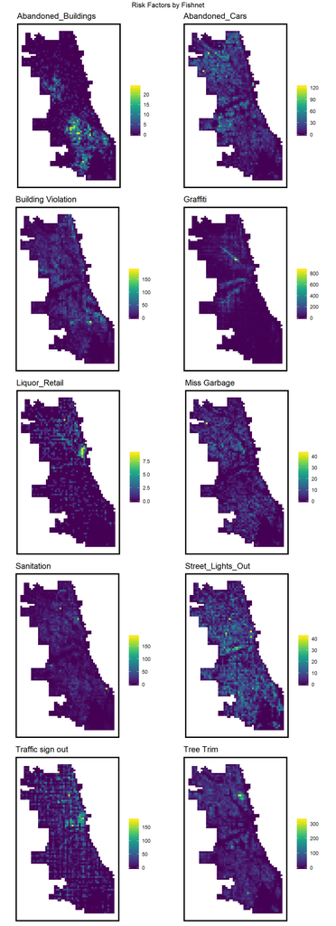

```r
vars_net <-
  rbind(missgarbage,streetLightsOut,
        liquorRetail, graffiti, sanitation,abandonBuildings,abandonCars,Buildingviolation,Treetrim,Trafficsignout) %>%
  st_join(., fishnet, join=st_within) %>%
  st_set_geometry(NULL) %>%
  group_by(uniqueID, Legend) %>%
  summarize(count = n()) %>%
  full_join(fishnet) %>%
  spread(Legend, count, fill=0) %>%
  st_sf() %>%
  dplyr::select(-`<NA>`) %>%
  na.omit()

vars_net.long <-
  vars_net %>%
  gather(Variable, value, -geometry, -uniqueID)

vars <- unique(vars_net.long$Variable)
mapList <- list()

for(i in vars){
  mapList[[i]] <-
    ggplot() +
      geom_sf(data = filter(vars_net.long, Variable == i), aes(fill=value), colour=NA) +
      scale_fill_viridis(name="") +
      labs(title=i) +
      mapTheme()}

do.call(grid.arrange,c(mapList, ncol =2, top = "Risk Factors by Fishnet"))
```

## 3.2 Feature engineering - Nearest neighbor features

There are the maps of distance by nearest risk factors. It calculates the nearest neighbor distance. The average nearest neighbor distance is likely a better approach for understanding local exposure to risk factors.

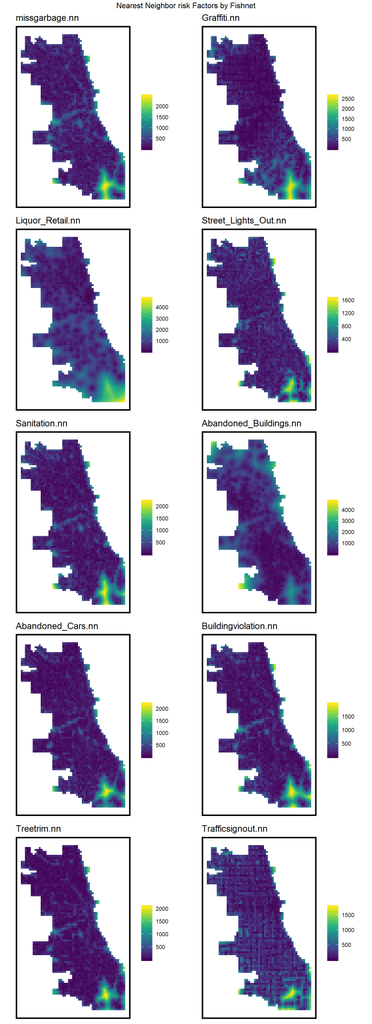

```r
nn_function <- function(measureFrom,measureTo,k) {
  measureFrom_Matrix <-
    as.matrix(measureFrom)
  measureTo_Matrix <-
    as.matrix(measureTo)
  nn <-
    get.knnx(measureTo, measureFrom, k)$nn.dist
    output <-
      as.data.frame(nn) %>%
      rownames_to_column(var = "thisPoint") %>%
      gather(points, point_distance, V1:ncol(.)) %>%
      arrange(as.numeric(thisPoint)) %>%
      group_by(thisPoint) %>%
      summarize(pointDistance = mean(point_distance)) %>%
      arrange(as.numeric(thisPoint)) %>%
      dplyr::select(-thisPoint) %>%
      pull()

  return(output)
}

vars_net$missgarbage.nn =
    nn_function(st_coordinates(st_centroid(vars_net)), st_coordinates(missgarbage), 3)

vars_net$Graffiti.nn =
    nn_function(st_coordinates(st_centroid(vars_net)), st_coordinates(graffiti), 3)

vars_net$Liquor_Retail.nn =
    nn_function(st_coordinates(st_centroid(vars_net)), st_coordinates(liquorRetail), 3)

vars_net$Street_Lights_Out.nn =
    nn_function(st_coordinates(st_centroid(vars_net)), st_coordinates(streetLightsOut), 3)

vars_net$Sanitation.nn =
    nn_function(st_coordinates(st_centroid(vars_net)), st_coordinates(sanitation), 3)

vars_net$Abandoned_Buildings.nn =
    nn_function(st_coordinates(st_centroid(vars_net)), st_coordinates(abandonBuildings), 3)

vars_net$Abandoned_Cars.nn =
    nn_function(st_coordinates(st_centroid(vars_net)), st_coordinates(abandonCars), 3)

vars_net$Buildingviolation.nn =
    nn_function(st_coordinates(st_centroid(vars_net)), st_coordinates(Buildingviolation), 3)

vars_net$Treetrim.nn =
    nn_function(st_coordinates(st_centroid(vars_net)), st_coordinates(Treetrim), 3)

vars_net$Trafficsignout.nn =
    nn_function(st_coordinates(st_centroid(vars_net)), st_coordinates(Trafficsignout), 3)


vars_net.long.nn <-
  vars_net %>%
  dplyr::select(ends_with(".nn")) %>%
  gather(Variable, value, -geometry, -uniqueID)

vars <- unique(vars_net.long.nn$Variable)
mapList <- list()

for(i in vars){
  mapList[[i]] <-
    ggplot() +
      geom_sf(data = filter(vars_net.long.nn, Variable == i), aes(fill=value), colour=NA) +
      scale_fill_viridis(name="") +
      labs(title=i) +
      mapTheme()}

do.call(grid.arrange,c(mapList, ncol =2, top = "Nearest Neighbor risk Factors by Fishnet"))
```

## 3.3 Feature Engineering - Measure distance to one point

It also may be reasonable to measure distance to a single point, like the centroid for the Logan Square neighbor - Chicago’s neighborhood filled with beautiful architecture, lovely parks and a great mix of bars and restaurants.

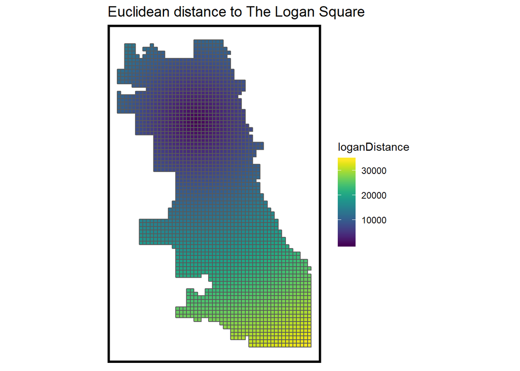

```r
loganPoint <-
  neighborhoods %>%
  filter(name == "Logan Square") %>%
  st_centroid()

vars_net$loganDistance =
  st_distance(st_centroid(vars_net),loganPoint) %>%
  as.numeric()

ggplot() +
  geom_sf(data=vars_net, aes(fill=loganDistance)) +
  scale_fill_viridis() +
  labs(title="Euclidean distance to The Logan Square") +
  mapTheme()
```

```r
final_net <-
  left_join(theft_net, st_set_geometry(vars_net, NULL), by="uniqueID")
final_net <-
  st_centroid(final_net) %>%
    st_join(., dplyr::select(neighborhoods, name)) %>%
    st_join(., dplyr::select(policeDistricts, District)) %>%
      st_set_geometry(NULL) %>%
      left_join(dplyr::select(final_net, geometry, uniqueID)) %>%
      st_sf() %>%
  na.omit()
```

# 4.1 Exploring the spatial structure of theft cases

In this part, it creates a neighbor and the spatial weights matrix. In addition, it plots the Moran’s I which is used for checking spatial autocorrelation on a local scale. While the null hypothesis for Global Moran’s I is that the count of theft is randomly distributed across the study area. Two more useful test statistics are output including the p-value and Significiant Hotspots, defined as those grid cells with p-values <= 0.05.

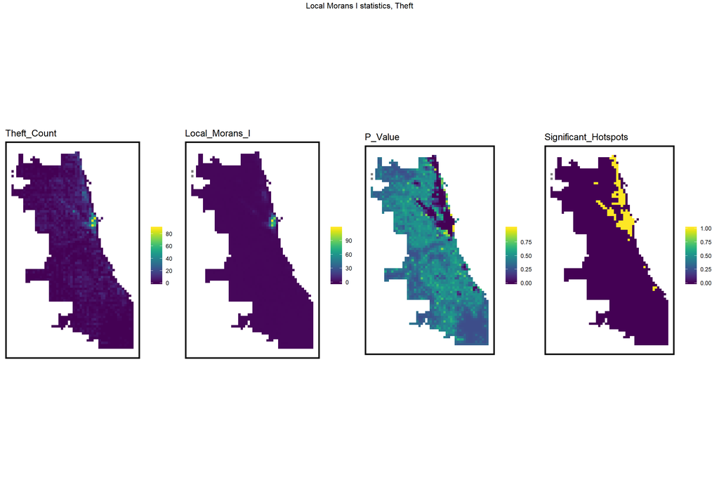

```r
final_net.nb <- poly2nb(final_net, queen=TRUE)
final_net.weights <- nb2listw(final_net.nb, style="W", zero.policy=TRUE)

final_net.localMorans <-
  cbind(
    as.data.frame(localmoran(final_net$counttheft, final_net.weights)),
    as.data.frame(final_net, NULL)) %>%
    st_sf() %>%
    dplyr::select(Theft_Count = counttheft,
                  Local_Morans_I = Ii,
                  P_Value = `Pr(z > 0)`) %>%
    mutate(Significant_Hotspots = ifelse(P_Value <= 0.05, 1, 0)) %>%
    gather(Variable, Value, -geometry)

vars <- unique(final_net.localMorans$Variable)
varList <- list()

for(i in vars){
  varList[[i]] <-
    ggplot() +
      geom_sf(data = filter(final_net.localMorans, Variable == i), aes(fill = Value), colour=NA) +
      scale_fill_viridis(name="") +
      labs(title=i) +
      mapTheme()}

do.call(grid.arrange,c(varList, ncol = 4, top = "Local Morans I statistics, Theft"))
```

```r
final_net <-
  final_net %>%
  mutate(theft.isSig = ifelse(localmoran(final_net$counttheft,
                                            final_net.weights)[,5] <= 0.0000001, 1, 0)) %>%
  mutate(theft.isSig.dist = nn_function(st_coordinates(st_centroid(final_net)),
                                           st_coordinates(st_centroid(
                                             filter(final_net, theft.isSig == 1))), 1 ))
```

## 4.2 Correlation Test

Here the test is used to check the Pearson correlation between theft counts and risk factors. These plots also can indicate the different directions of association between the theft counts and nearest neighbor features.

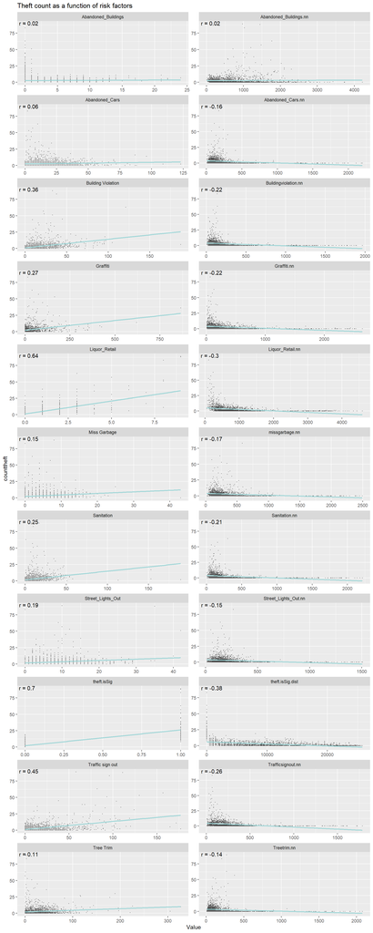

```r
correlation.long <-
  st_set_geometry(final_net, NULL) %>%
    dplyr::select(-uniqueID, -cvID, -loganDistance, -name, -District) %>%
    gather(Variable, Value, -counttheft)

correlation.cor <-
  correlation.long %>%
    group_by(Variable) %>%
    summarize(correlation = cor(Value, counttheft, use = "complete.obs"))

ggplot(correlation.long, aes(Value, counttheft)) +
  geom_point(size = 0.1) +
  geom_text(data = correlation.cor, aes(label = paste("r =", round(correlation, 2))),
            x=-Inf, y=Inf, vjust = 1, hjust = -.1) +
  geom_smooth(method = "lm", se = FALSE, colour = "#a2d7d8") +
  facet_wrap(~Variable, ncol = 2, scales = "free") +
  labs(title = "Theft count as a function of risk factors")
```

# 5.1 The histogram of dependant variable

There is the distribution of theft count in the histogram before. The distribution theft is far more skewed.

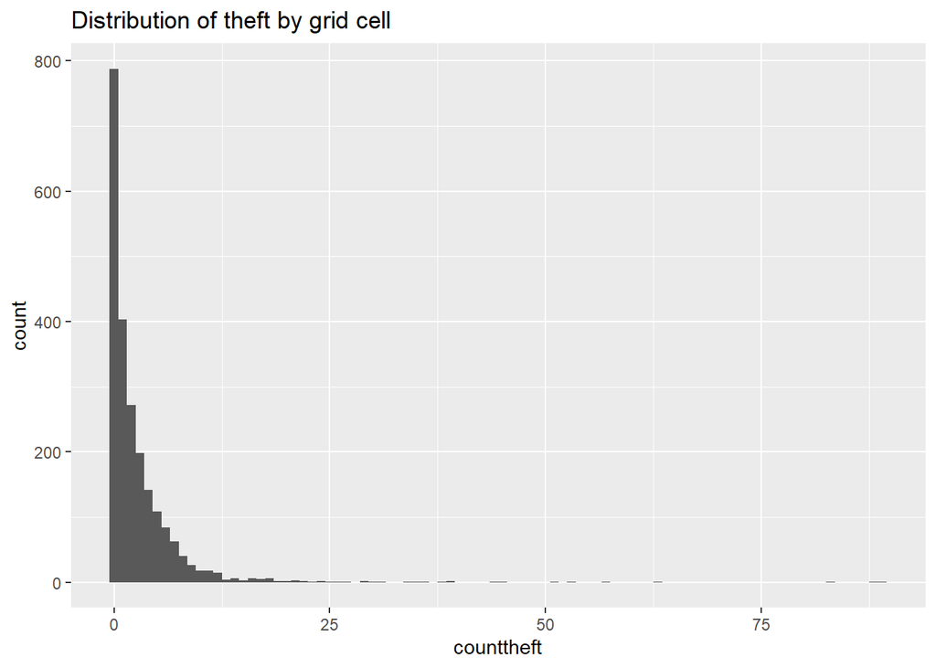

```r
ggplot(final_net, aes(counttheft)) +
  geom_histogram(binwidth = 1) +
  labs(title = "Distribution of theft by grid cell")
```